# Helen Hammond's Module 4 Project

### Date: Feb 22 2023

# Task 5 - Optional Bonus - California Housing Dataset

1. Practice more machine learning skills by working through 15.5 with the California Housing Dataset.
2. Follow the instructions all the way though loading the data, training and testing the data, visualizing the data, and choosing the best model from the 4 listed.
3. Customize your presentation and include helpful remarks to "tell a story with data".
4. Execute the notebook.
5. Add/commit/push your changes up to your GitHub repo.

## 1 - Loading the Data

Let’s load the dataset and familiarize ourselves with it. The fetch_california_housing function from the sklearn.datasets module returns a Bunch object containing the data and other information about the dataset

```python
from sklearn.datasets import fetch_california_housing

california = fetch_california_housing()
print(california.DESCR)
```

```
.. _california_housing_dataset:

California Housing dataset
--------------------------

**Data Set Characteristics:**

    :Number of Instances: 20640

    :Number of Attributes: 8 numeric, predictive attributes and the target

    :Attribute Information:
        - MedInc        median income in block group
        - HouseAge      median house age in block group
        - AveRooms      average number of rooms per household
        - AveBedrms     average number of bedrooms per household
        - Population    block group population
        - AveOccup      average number of household members
        - Latitude      block group latitude
        - Longitude     block group longitude

    :Missing Attribute Values: None

This dataset was obtained from the StatLib repository.
https://www.dcc.fc.up.pt/~ltorgo/Regression/cal_housing.html

The target variable is the median house value for California districts,
expressed in hundreds of thousands of dollars ($100,000).

This dataset was derived from the 1990 U.S. census, using one row per census
block group. A block group is the smallest geographical unit for which the U.S.
Census Bureau publishes sample data (a block group typically has a population
of 600 to 3,000 people).

An household is a group of people residing within a home. Since the average
number of rooms and bedrooms in this dataset are provided per household, these
columns may take surpinsingly large values for block groups with few households
and many empty houses, such as vacation resorts.

It can be downloaded/loaded using the
:func:`sklearn.datasets.fetch_california_housing` function.

.. topic:: References

    - Pace, R. Kelley and Ronald Barry, Sparse Spatial Autoregressions,
      Statistics and Probability Letters, 33 (1997) 291-297
```

We can confirm the number of samples (rows) and features (columns) by looking at the data array’s shape attribute, which shows that there are 20,640 rows and 8 columns:

```python
california.data.shape
```

```
(20640, 8)
```

Similarly, you can see that the number of target values—that is, the median house values—matches the number of samples by looking at the target array’s shape

```python
california.target.shape
```

```
(20640,)
```

The Bunch’s feature_names attribute contains the names that correspond to each column in the data array:

```python
california.feature_names
```

```
['MedInc',
 'HouseAge',
 'AveRooms',
 'AveBedrms',
 'Population',
 'AveOccup',
 'Latitude',
 'Longitude']
```

## 2 - Exploring the Data

Let’s use a pandas DataFrame to explore the data further. We’ll also use the DataFrame with Seaborn in the next section to visualize some of the data. First, let’s import pandas and set some options:

```python
import pandas as pd
pd.options.display.precision = 4
pd.options.display.max_columns = 9
pd.options.display.width = None
```

In the preceding set_option calls:

- 'precision' is the maximum number of digits to display to the right of each decimal point.
- The 'max_columns' setting enables pandas to show all the columns using multiple rows of output.
- 'display.width' specifies the width in characters. The value None tells pandas to auto-detect the display width.

Next, let’s create a DataFrame from the Bunch’s data, target and feature_names arrays. The first snippet below creates the initial DataFrame using the data in california.data and with the column names specified by california.feature_names. The second statement adds a column for the median house values stored in california.target:

```python
california_df = pd.DataFrame(california.data, columns=california.feature_names)
california_df['MedHouseValue'] = pd.Series(california.target)
california_df.head()
```

|  | MedInc | HouseAge | AveRooms | AveBedrms | Population | AveOccup | Latitude | Longitude | MedHouseValue |
| --- | --- | --- | --- | --- | --- | --- | --- | --- | --- |
| 0 | 8.3252 | 41.0 | 6.9841 | 1.0238 | 322.0 | 2.5556 | 37.88 | -122.23 | 4.526 |
| 1 | 8.3014 | 21.0 | 6.2381 | 0.9719 | 2401.0 | 2.1098 | 37.86 | -122.22 | 3.585 |
| 2 | 7.2574 | 52.0 | 8.2881 | 1.0734 | 496.0 | 2.8023 | 37.85 | -122.24 | 3.521 |
| 3 | 5.6431 | 52.0 | 5.8174 | 1.0731 | 558.0 | 2.5479 | 37.85 | -122.25 | 3.413 |
| 4 | 3.8462 | 52.0 | 6.2819 | 1.0811 | 565.0 | 2.1815 | 37.85 | -122.25 | 3.422 |

Let’s get a sense of the data in each column by calculating the DataFrame’s summary statistics. Note that the median income and house values (again, measured in hundreds of thousands) are from 1990 and are significantly higher today:

```python
california_df.describe()
```

|  | MedInc | HouseAge | AveRooms | AveBedrms | Population | AveOccup | Latitude | Longitude | MedHouseValue |
| --- | --- | --- | --- | --- | --- | --- | --- | --- | --- |
| count | 20640.0000 | 20640.0000 | 20640.0000 | 20640.0000 | 20640.0000 | 20640.0000 | 20640.0000 | 20640.0000 | 20640.0000 |
| mean | 3.8707 | 28.6395 | 5.4290 | 1.0967 | 1425.4767 | 3.0707 | 35.6319 | -119.5697 | 2.0686 |
| std | 1.8998 | 12.5856 | 2.4742 | 0.4739 | 1132.4621 | 10.3860 | 2.1360 | 2.0035 | 1.1540 |
| min | 0.4999 | 1.0000 | 0.8462 | 0.3333 | 3.0000 | 0.6923 | 32.5400 | -124.3500 | 0.1500 |
| 25% | 2.5634 | 18.0000 | 4.4407 | 1.0061 | 787.0000 | 2.4297 | 33.9300 | -121.8000 | 1.1960 |
| 50% | 3.5348 | 29.0000 | 5.2291 | 1.0488 | 1166.0000 | 2.8181 | 34.2600 | -118.4900 | 1.7970 |
| 75% | 4.7432 | 37.0000 | 6.0524 | 1.0995 | 1725.0000 | 3.2823 | 37.7100 | -118.0100 | 2.6472 |
| max | 15.0001 | 52.0000 | 141.9091 | 34.0667 | 35682.0000 | 1243.3333 | 41.9500 | -114.3100 | 5.0000 |

## 3 - Visualising the Features

It’s helpful to visualize your data by plotting the target value against each feature—in this case, to see how the median home value relates to each feature. To make our visualizations clearer, let’s use DataFrame method sample to randomly select 10% of the 20,640 samples for graphing purposes:

```python
sample_df = california_df.sample(frac=0.1, random_state=17)
```

Next, we’ll use Matplotlib and Seaborn to display scatter plots of each of the eight features. Seaborn’s are more attractive and require less code, so we’ll use Seaborn to create the following scatter plots. First, we import both libraries and use Seaborn function set to scale each diagram’s fonts to two time their default size:

```python
import matplotlib.pyplot as plt
import seaborn as sns

sns.set(font_scale=2)
sns.set_style('whitegrid')
```

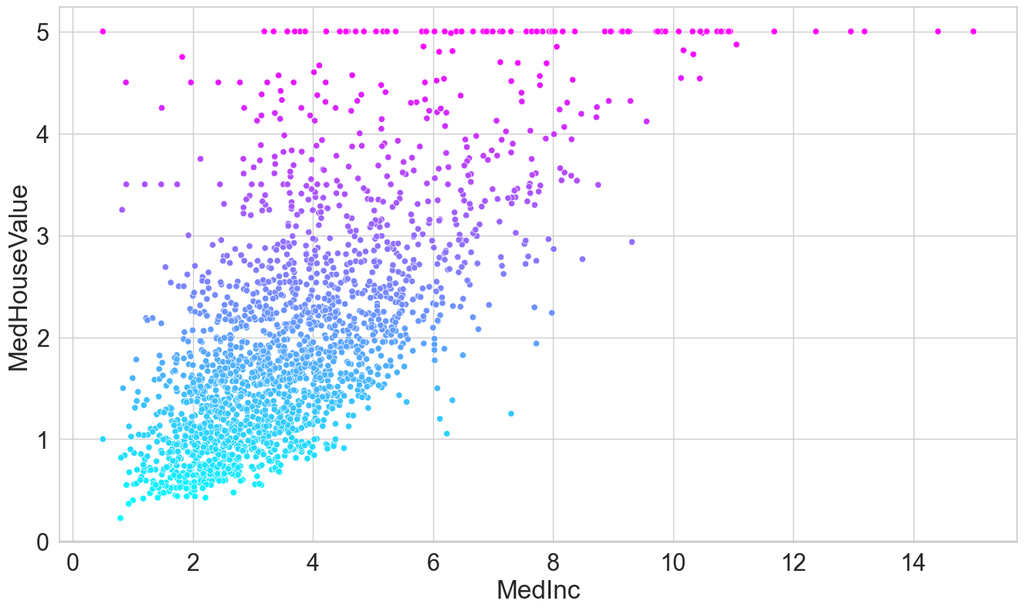

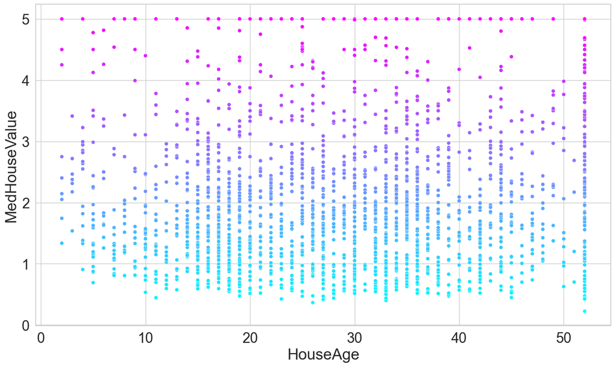

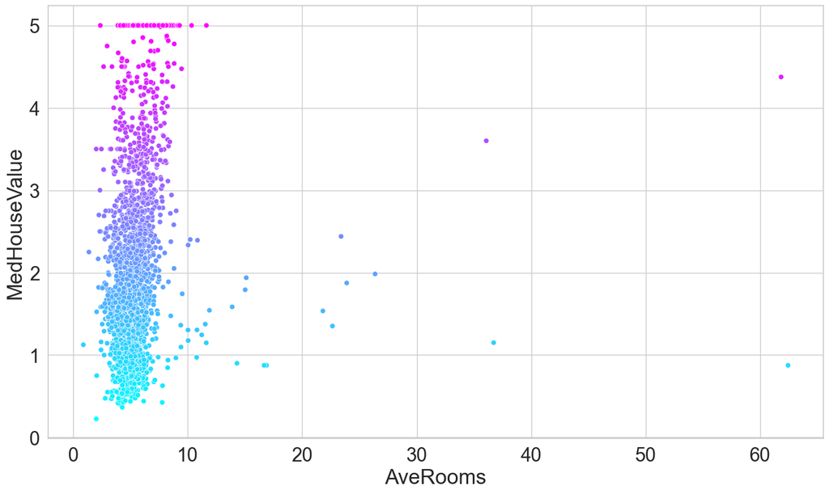

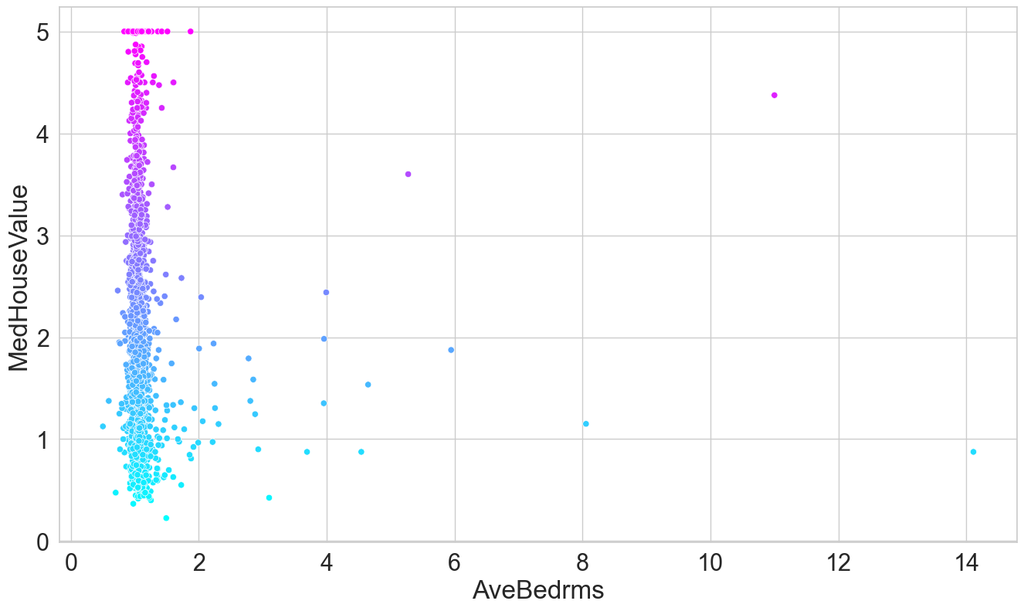

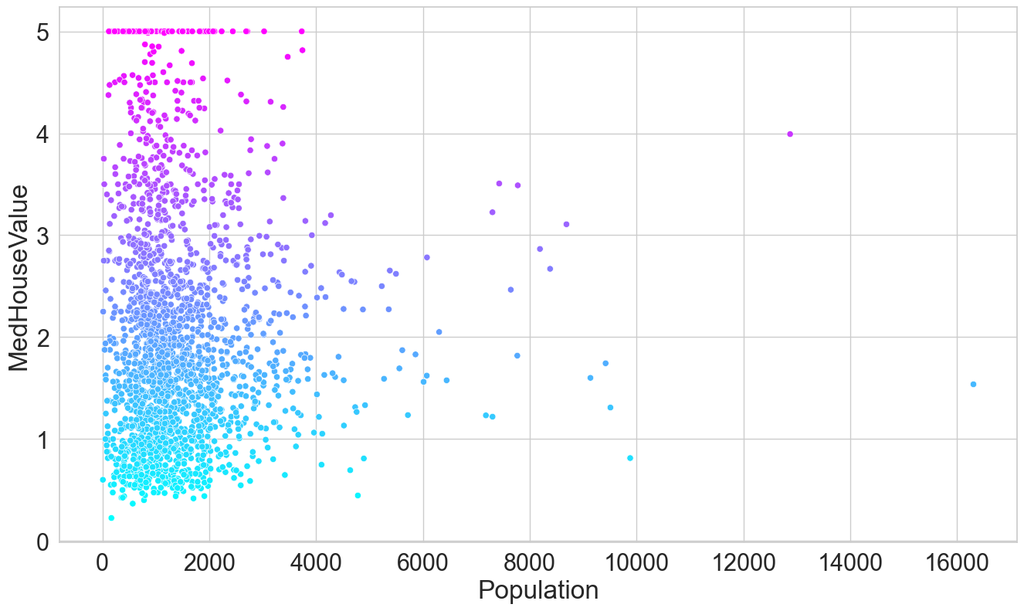

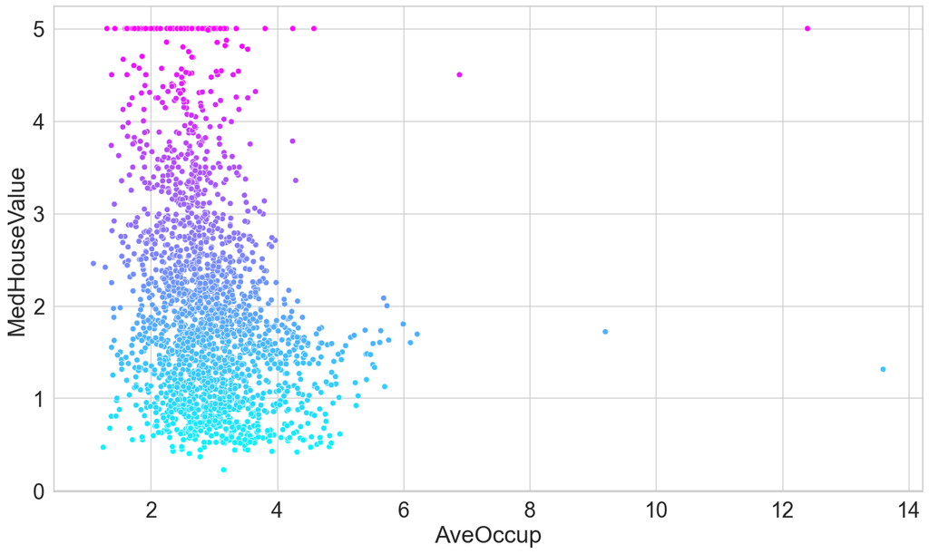

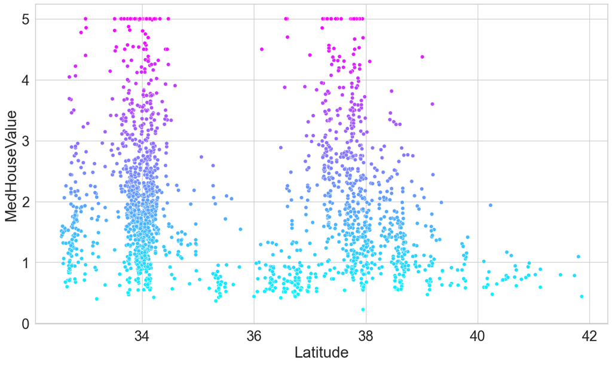

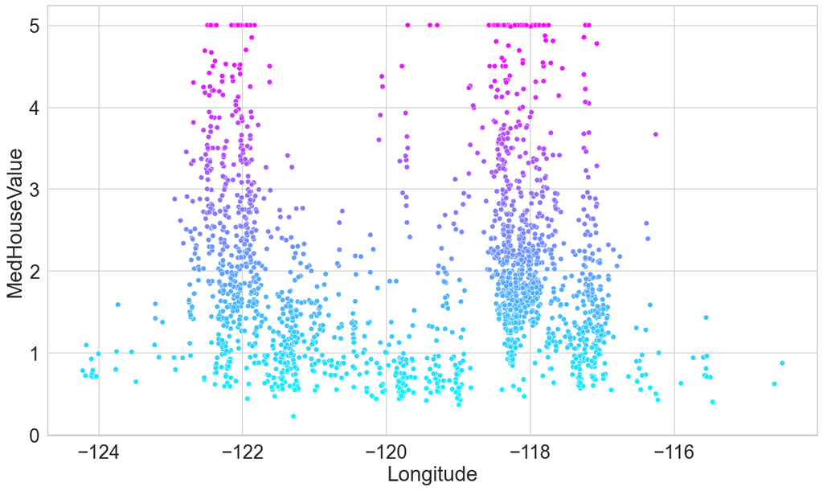

```python
for feature in california.feature_names:
    plt.figure(figsize=(16, 9))
    sns.scatterplot(data=sample_df, x=feature,
    y='MedHouseValue', hue='MedHouseValue',
    palette='cool', legend=False)
```

## 4 - Splitting the Data for Training and Testing

Once again, to prepare for training and testing the model, let’s break the data into training and testing sets using the train_test_split function then check their sizes:

```python
from sklearn.model_selection import train_test_split

X_train, X_test, y_train, y_test = train_test_split(
    california.data, california.target, random_state=11)

X_train.shape
```

```
(15480, 8)
```

```python
X_test.shape
```

```
(5160, 8)
```

We used train_test_split’s keyword argument random_state to seed the random number generator for reproducibility.

## 5 - Training the Model

Let’s create a LinearRegression estimator and invoke its fit method to train the estimator using X_train and y_train:

```python
from sklearn.linear_model import LinearRegression

linear_regression = LinearRegression()

linear_regression.fit(X=X_train, y=y_train)
```

```
LinearRegression()
```

Multiple linear regression produces separate coefficients for each feature (stored in coeff*) in the dataset and one intercept (stored in intercept*):

```python
for i, name in enumerate(california.feature_names):
    print(f'{name:>10}: {linear_regression.coef_[i]}')
```

```
    MedInc: 0.4377030215382206
  HouseAge: 0.009216834565797749
  AveRooms: -0.10732526637360926
 AveBedrms: 0.6117133073918087
Population: -5.756822009275742e-06
  AveOccup: -0.003384566465716442
  Latitude: -0.4194818609649067
 Longitude: -0.4337713349874023
```

## 6 - Testing the Model

Now, let’s test the model by calling the estimator’s predict method with the test samples as an argument. As we’ve done in each of the previous examples, we store the array of predictions in predicted and the array of expected values in expected:

```python
predicted = linear_regression.predict(X_test)

expected = y_test
```

```python
predicted[:5]
```

```
array([1.25396876, 2.34693107, 2.03794745, 1.8701254 , 2.53608339])
```

```python
expected[:5]
```

```
array([0.762, 1.732, 1.125, 1.37 , 1.856])
```

## 7 - Visualizing the Expected vs. Predicted Prices

Let’s create a DataFrame containing columns for the expected and predicted values:

```python
df = pd.DataFrame()
df['Expected'] = pd.Series(expected)
df['Predicted'] = pd.Series(predicted)
```

Now let’s plot the data as a scatter plot with the expected (target) prices along the x-axis and the predicted prices along the y-axis:

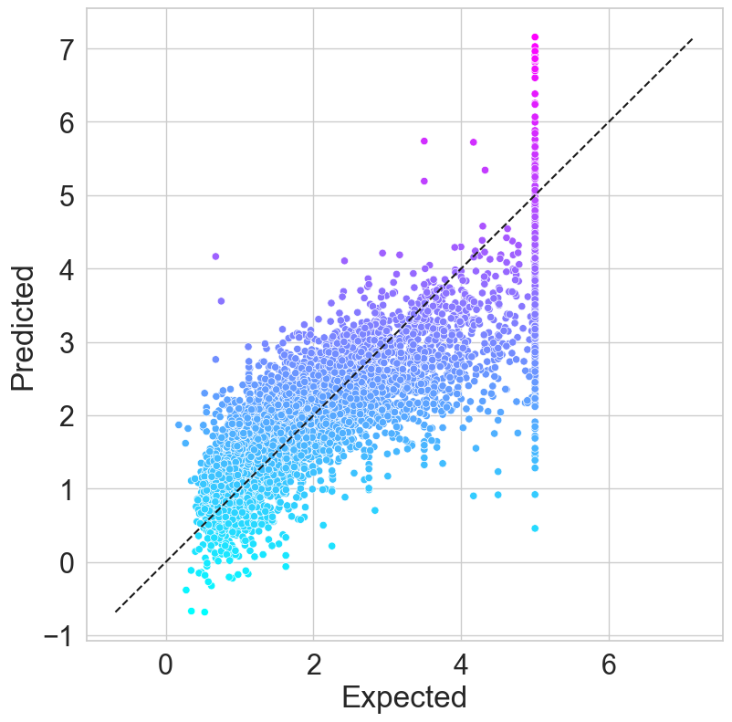

```python
figure = plt.figure(figsize=(9, 9))
axes = sns.scatterplot(data=df, x='Expected', y='Predicted',
    hue='Predicted', palette='cool', legend=False)
start = min(expected.min(), predicted.min())
end = max(expected.max(), predicted.max())
line = plt.plot([start, end], [start, end], 'k--')
```

The snippet above displays a line between the points representing the lower-left corner of the graph (start, start) and the upper-right corner of the graph (end, end). The third argument ('k--') indicates the line’s style. The letter k represents the color black, and the -- indicates that plot should draw a dashed line:

## 8 - Choosing the Best Model

Let’s try several estimators to determine whether any produces better results than the LinearRegression estimator. In this example, we’ll use the linear_regression estimator we already created as well as ElasticNet, Lasso and Ridge regression estimators (all from the sklearn.linear_model module)

```python
from sklearn.linear_model import ElasticNet, Lasso, Ridge

estimators = {
    'LinearRegression': linear_regression,
    'ElasticNet': ElasticNet(),
    'Lasso': Lasso(),
    'Ridge': Ridge()
    }
```

Once again, we’ll run the estimators using k-fold cross-validation with a KFold object and the cross_val_score function. Here, we pass to cross_val_score the additional keyword argument scoring='r2', which indicates that the function should report the R 2 scores for each fold.

```python
from sklearn.model_selection import KFold, cross_val_score

for estimator_name, estimator_object in estimators.items():
    kfold = KFold(n_splits=10, random_state=11, shuffle=True)
    scores = cross_val_score(estimator=estimator_object,
    X=california.data, y=california.target, cv=kfold,
        scoring='r2')
    print(f'{estimator_name:>16}: ' +
        f'mean of r2 scores={scores.mean():.3f}')
```

```
LinearRegression: mean of r2 scores=0.599
      ElasticNet: mean of r2 scores=0.423
           Lasso: mean of r2 scores=0.285
           Ridge: mean of r2 scores=0.599
```

1.0 is the best score. Therefore, we can conlude that LinearRegression and Ridge are the best models for this dataset, with 0.599 each.